# AlessandroKerr_A8

Alessandro Kerr

Nov. 16, 2021

#6 POINT WORK

The purpose of this assignment is to complete a difference-in-differences analysis of the Antioch BART station. The map below outlines the PUMA of interest (PUMA 01309) and the Antioch BART station.

[interactive chart not shown]

For reference, the population of all Bay Area counties can be seen below. This provides background for the difference-in-difference analysis.

[interactive chart not shown]

Now, Bay Area BART ridership can be seen by PUMA.

[interactive chart not shown]

From here, a Mahalnobis Distribution was completed between the years of 2014 and 2017. This provides the basis for the DiD analysis, as it creates the 10 closest “pre-treatment” PUMAs that can be used for comparison.

A map of the treatment PUMA (01309) and its 10 most similar “neighbours” in terms of BART ridership trends can be seen below.

[interactive chart not shown]

Now, the data can be visualized and plotted as a result of the 2018 BART station at Antioch. See the comparative graph below; it shows that before 2017 the trends were similar across all PUMAs, but PUMA 01309 had a sharp increase with the building of the station in 2018.

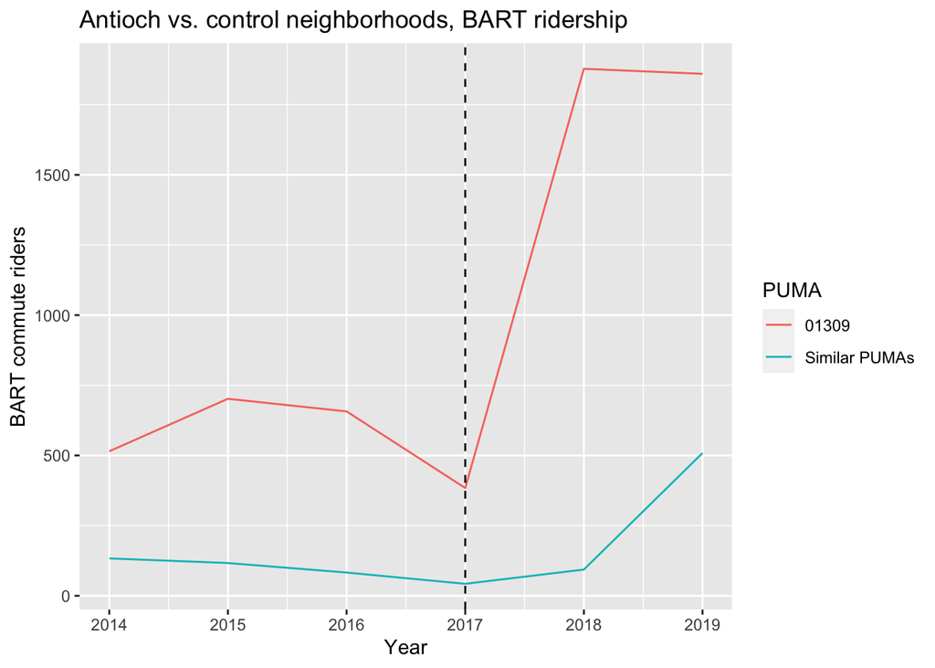

The results can be analyzed for their statistical significance. See the linear model results below.

```
##
## Call:
## lm(formula = bart ~ treated * time, data = transit_did)
##
## Residuals:
##     Min      1Q  Median      3Q     Max
## -990.00 -110.90  -69.93   77.28 1222.07
##
## Coefficients:
##              Estimate Std. Error t value Pr(>|t|)
## (Intercept)    110.90      52.58   2.109  0.03898 *
## treated        513.77     174.40   2.946  0.00453 **
## time           104.03      74.36   1.399  0.16679
## treated:time   645.30     246.63   2.616  0.01115 *
## ---
## Signif. codes:  0 '***' 0.001 '**' 0.01 '*' 0.05 '.' 0.1 ' ' 1
##
## Residual standard error: 288 on 62 degrees of freedom
## Multiple R-squared:  0.4838, Adjusted R-squared:  0.4589
## F-statistic: 19.37 on 3 and 62 DF,  p-value: 5.613e-09
```

#6.5 POINT WORK

Similar to the textbook example, the results found above are statistically significant. There is a positive effect between time and BART ridership, but it is not significant. Meanwhile, the combined treated*time is significant in itself. In more colloquial terms, this means that the combined effect of the new BART station and increasing yearly ridership with time does have a significant effect. However, over time itself, the effect of BART ridership increasing is not significant. There are several assumptions and choices that can be said regarding the above analysis:

1. One important aspect to consider is the inclusion of the ‘bart’ variable itself. Firstly, it assumes that surveyee’s correctly chose “Subway or elevated car” in the ACS survey to represent BART trains. Also, that the majority of the BART trips are work trips (and not recreation). In addition, the ‘bart’ variable may not be entirely representative of the benefits of a new bart station. While ridership is certainly important, it can only be measured as outbound trips (originating from Antioch station), and not inbound trips. Furthermore, value of the station can be measured in terms of more than just ridership, as the commerical and residential development benefits are not incorporated into the analysis.
2. Due to the limited time-range for the data, it is possible that the combined time/treated effects simply cannot be seen yet. Especially in this case, the fact that there are only 2 years of post-treatment analysis is certainly limiting.
3. One additional consideration is the geography used for the analysis. The antioch station was further West (towards San Francisco), meaning the treated geography did not even include the Antioch station. Perhaps the analysis could be re-completed using PUMA = 01308.
4. During the analysis, the 10 smallest Mahalanobis values were chosen. Perhaps taking more or less would change the significance of the analysis.
5. While bart ridership was the only variable considered to find the matching geographies, other variables (income, race, educational attainment) could have been controlled for to find closer matches to the treated geography.
6. Due to the relatively small sample size of PUMs data, there is additional variability with the results. To combat this error, replicate weights will be considered, and the model will be re-calculated.

#7-POINT WORK

Now, the model will be re-calculated using the weights included in the PUMs data. This was completed by grouping the data by each year and PUMA. From here, the ridership data was joined. This allowed the linear model to be run 80 times, each with a different replicate weight.

```
##
## Call:
## svyglm(formula = bart ~ treated * time, family = gaussian(),
##     design = design)
##
## Survey design:
## svrepdesign.default(data = transit_did_2, type = "ACS", repweights = pums_reps[,
##     3:83], weights = ~PWGTP)
##
## Coefficients:
##              Estimate Std. Error t value Pr(>|t|)
## (Intercept)    284.11      16.11  17.637  < 2e-16 ***
## treated        350.72      27.94  12.551 4.33e-15 ***
## time           408.03      47.74   8.547 2.22e-10 ***
## treated:time   687.84     136.82   5.027 1.22e-05 ***
## ---
## Signif. codes:  0 '***' 0.001 '**' 0.01 '*' 0.05 '.' 0.1 ' ' 1
##
## (Dispersion parameter for gaussian family taken to be 9467879)
##
## Number of Fisher Scoring iterations: 2
```